# Assessment of farmers on their knowledge regarding pesticide usage and biosafety - ScienceDirect

[figure not shown]

[figure not shown]

## [Saudi Journal of Biological Sciences](https://www.sciencedirect.com/journal/saudi-journal-of-biological-sciences)

[Volume 26, Issue 7](https://www.sciencedirect.com/journal/saudi-journal-of-biological-sciences/vol/26/issue/7), November 2019, Pages 1903-1910

# Original article Assessment of farmers on their knowledge regarding pesticide usage and biosafety

[MuhammadMubushar](https://www.sciencedirect.com/science/article/pii/S1319562X1930035X#!)[Fahad O.Aldosari](https://www.sciencedirect.com/science/article/pii/S1319562X1930035X#!)[Mirza B.Baig](https://www.sciencedirect.com/science/article/pii/S1319562X1930035X#!)[Bader M.Alotaibi](https://www.sciencedirect.com/science/article/pii/S1319562X1930035X#!)[Abdul QaderKhan](https://www.sciencedirect.com/science/article/pii/S1319562X1930035X#!)

Under a Creative Commons [license](https://creativecommons.org/licenses/by-nc-nd/4.0/)

Open access

## Abstract

### Purpose

Inappropriate application of pesticides is quite common in the study area, causing health issues and in some cases fatalities. The intent of the current study is to gauge the farmers’ level of knowledge on the safe usage of pesticides and biosafety to keep the famers healthy through the focused extension programs.

### Methodology

The study is carried out in 41 union councils of Tehsil Sahiwal, District Sahiwal, Punjab, Pakistan. Data are collected through a cluster sampling technique by conducting face-to-face interviews. Statistical analysis is used to determine relationships and interpret them.

### Results

The findings show that the majority of farmers (87.2%) earn their livelihoods from farming and 2.1% are traders. More than half of the respondents (51.8%) own small land-holdings with an area of 4–8 ha, with only 16.4% having a land area of more than 12 ha. The results also reveal that the majority of respondents obtain information from private agents and only about one third (34.4%) respondents get information on the safe usage of pesticides from the Department of Agriculture (Extension). The internet has emerged as a fast and reliable source of information in the new paradigm; however, only 14.4% of the respondents take advantage of this economical and fast information tool/medium. The findings also reveal that the farmers employ unhealthy and poor practices by not following the recommendations regarding the safe usage of pesticides. The study also reveals that more than half of the farmers (54.4%) use unsafe storage practices on their farms, and about 48.2% do not follow the instructions.

### Conclusions

Inappropriate application of pesticides can have negative effects on human health and the adoption safety measures are necessary to avoid the harmful effects of pesticides. Due to high illiteracy in the area, farmers mainly seek advice of neighboring farmers, having ignorance on the biosafety issues. Variables like education level, land ownership, total land size and the trainings on safe pesticide usage significantly influence the knowledge level of farmers on the safe usage of pesticides.

### Recommendations

Farmers do not follow the recommendations of the extension department or the instructions printed on pesticide bottles/containers, therefore educational (formal and informal) and training programs are necessary on the safe pesticide usage to upgrade their skills and expertise on safe usage of pesticides and the importance of biosafety.

## Keywords

Farmers level of knowledge

Information sources

Trainings

Safe pesticide usage

Biosafety

## 1. Introduction

The economy of Pakistan primarily depends on agriculture; it contributes about 19.8% to the gross domestic product and 42.5% of rural people are associated with agriculture (GOP, 2015–16). Worldwide, about 1.8 billion people are engaged in agriculture and use pesticides to control insects, pests, and diseases to ensure healthy crops and food security (Grube et al., 2011). Synthetic and naturally occurring chemical (plant exudates) pesticides aid in controlling insect pests and eradicating weeds that compete with field crops (Khan et al., 2010). There are 1500 types of chemicals used as pesticides worldwide, and owing to their chemical nature, pesticides can cause serious environmental and health problems (Bolognesi and Merlo, 2011). In Pakistan, 108 types of insecticide, 39 kinds of herbicide, 30 types of fungicide, 6 types of rodenticide, and 5 types of acaricide are used on different crops (Anwar et al., 2011, Zia et al., 2009). It is estimated that global expenditure on pesticides increased significantly from 2008 to 2012. In 2008–2012, the total expenditure on pesticides was about $56 billion (McDougall, 2012).

Around 2 million tons of pesticides are used yearly in agriculture production, out of which about 69% is used in Europe and the US alone (Abhilash and Singh, 2009). Human exposure to pesticides results in a number of harmful effects depending on the type of pesticide and duration of exposure. The most common signs of exposure are headaches, excessive salivation, lacrimation, nausea, diarrhea, respiratory depression, seizures, and loss of consciousness (Medline Plus, 2015, PSEP, 2015). Similarly, research conducted by Kachaiyaphum et al. (2010) showed that farmers were experiencing different kinds of health problem due to the use of pesticides, including dizziness (38%), headaches (31%), and nausea or vomiting (27%). Luckily, the toxic residues of pesticides in the environment and food can be minimized by educating farmers and exposing them to training on the safe usage of pesticides (Ahmed et al., 2011, Khan et al., 2010).

However, more research on higher-order controls to reduce pesticide exposure, understand the reasons for the poor utilization of personal protection equipment (PPE), and identify effective training methods is needed (MacFarlane et al., 2013). Several previous studies focused on providing education on pesticide safety and protection standards for workers in order to mitigate health risks; owing to their insufficient knowledge of the harmful effects of pesticide exposure, farmers and farm workers rarely adopt precautionary measures while applying pesticides (Khan, 2012, Ejaz et al., 2004).

Pakistan, an agricultural country with various agro-ecological zones and climates, produces a wide variety of crops; therefore, the use of pesticides in Pakistan has increased tremendously in the last few decades. Though [food production](https://www.sciencedirect.com/topics/earth-and-planetary-sciences/food-production) has increased substantially due to progress in [science and technology](https://www.sciencedirect.com/topics/earth-and-planetary-sciences/science-and-technology), the targets set by the government to meet national food demand always put pressure on farmers to increase grain production. In order to enhance crop production, farmers have expanded the use of pesticides and [fertilizers](https://www.sciencedirect.com/topics/earth-and-planetary-sciences/fertiliser) to meet the government’s food sufficiency targets. Nowadays, farmers fully rely on pesticides for increasing global agricultural productivity and protecting plantations from different insects, pests, and diseases. Developing countries account for only 20% of pesticide use at the global level; however, their casualty rates are very high due to pesticide poisoning (Kesavachandran et al., 2009). In developed countries, many studies have assessed farmers’ levels of knowledge of safe pesticide usage; however, no scientific study on this subject has been conducted in Central Punjab, Pakistan. Therefore, the present study was undertaken. It is anticipated that this study, due to its research-based findings, will help in exploring the knowledge levels of farmers and in identifying the problems they face regarding safe pesticide usage. Further, the outcomes of the study will contribute to devising policy instruments and developing extension programs for farmers regarding safe pesticide usage that will reduce the health risks.

## 2. Research methodology

This study is undertaken in the District of Sahiwal, Pakistan. The District of is administratively divided into two municipalities: Tehsil Sahiwal and Tehsil Chichawatni. Each Tehsil is further administratively divided into Union Councils (UCs). The District of Sahiwal consists of 81 UCs and approximately 531 villages. In Tehsil Sahiwal, there are 52 UCs and 315 villages, with 11 UCs falling in urban zones and 41 in rural zones.

A cluster sampling technique is used to obtain the cross-sectional data for this study (because each UC has a specific number of villages that make clusters). One village is selected randomly from each rural UC. Then, five farmers are interviewed from each village. The study included 205 farmers and are interviewed to collect data for the study’s purposes. Ten farmers refused to participate; therefore, incomplete questionnaires were excluded, making the final sample size 195 farmers.

A questionnaire was developed for this study to achieve its objectives. The Faculty of the Departments of Agricultural Extension as well as Plant Protection reviewed the formulated questionnaire, and necessary amendments were made in light of their comments. Initially, the questionnaire was prepared in English; however, later it was translated into the local language (Urdu) to avoid any problems with understanding. Before conducting the real interviews, the questionnaire was pretested by conducting interviews with 20 farmers in the area (who were not a part of the study) to check its smoothness and gauge how easy it was for the farmers to understand the questions. After receiving their feedback, further necessary amendments were made. In order to check the reliability and internal consistency of the pretested questionnaire, Cronbach’s alpha was calculated; a value of 0.71 was obtained.

All of the variables regarding knowledge level, sources of information, reasons for pesticide usage, and problems related to safe pesticide usage are clearly defined and labeled for data analysis. The demographic characteristics of the respondents are assessed using descriptive statistics, mainly through frequency distributions and percentages.

The data are coded, entered into an Excel file, and then analyzed using the Statistical Package for Social Sciences version 21. A logit regression model is employed to test the effect of the independent variables on the variance of the dependent variables.

## 3. Results and discussion

### 3.1. Demographic characteristics of the farmers

The socioeconomic characteristics studied are the age of the farmers, their education level, their main occupation, their annual income from agriculture and other sources, the nature of their farm ownership, the total land size, the land under cultivation, and their total experience (in years) with using pesticides.

#### 3.1.1. Age and education level of the respondents

Age and level of education are measured using well-defined ordinal scale categories. Table 1 shows that the highest percentage of respondents (34.9%) belonged to the 30–39 age group, followed by 29.2% in the 40–49 group and 20.5% in the 20–29 group. The smallest number of respondents (15.4%) is in the above 50-age group.

Table 1. Socioeconomic characteristics of the respondents (N = 195).

| *Age of the respondents (Years)* |  |  |  |  |
| --- | --- | --- | --- | --- |
|  | 20–30 | 30–40 | 40–50 | > 50 |
| Percentage (n) | 20.5 (40) | 34.9 (68) | 29.2 (57) | 15.4 (30) |
| *Education level of the respondents* |  |  |  |  |
|  | Illiterate | Secondary | Matriculation | Higher study |
| Percentage (n) | 39.5 (77) | 26.2 (51) | 20.0 (39) | 14.4 (28) |
| *Main source of earning* |  |  |  |  |
|  | Farming | Trader | Govt. + farming | Others |
| Percentage (n) | 87.2 (1 7 0) | 2.1 (4) | 10.8 (21) | 0.0 |
| *Income per annum of the respondents (Millions PKR)* |  |  |  |  |
|  | 0–0.5 | 0.5–1.0 | 1.0–1.5 | > 1.5 |
| Percentage (n) | 8.2 (16) | 49.2 (96) | 26.2 (51) | 16.4 (21) |
| *Total land size (hectares)* |  |  |  |  |
|  | 0–4 | 4–8 | 8–12 | >12 |
| Percentage (n) | 7.2 (14) | 51.8 (1 0 1) | 24.6 (48) | 16.4 (32) |
| *Respondents experience in using pesticide using (Years)* |  |  |  |  |
|  | 5–10 | 11–15 | 16–20 | >20 |
| Percentage (n) | 37.9 (74) | 41.0 (80) | 16.9 (33) | 4.1 (8) |

Regarding education level, the majority of the respondents are illiterate, accounting for 39.5% of the sampled population; secondary and matriculation education followed with 26.2% and 20.0%, respectively. Respondents with a higher level of education account for only 14.4%. According to Rios-Gonzalez et al. (2013), literate farmers have a better understanding of the effects of pesticides on health and environment than illiterate ones. These results are in accordance with Khan and Iqbal (2009), who reported that the majority of farmers in Pakistan have a low level of education, with only 6% having received a university education.

#### 3.1.2. Income sources and total income of the respondents

Farming is the main occupation in Pakistan; the country’s economy is based on the agricultural sector. The majority of people are associated with agriculture directly or indirectly for their livelihoods. As the data in Table 1 indicate, farming is the main occupation of 87.2% of respondents; 10.8% hold government jobs in addition to farming. The rest of the respondents (2.1%) are recognized as traders, while no respondents had other professions. Bhutto and Bazmi (2007) reported similar results: the majority of farmers have small parcels of land, and agriculture is their subsistence livelihood.

#### 3.1.3. Land ownership and area under cultivation

The majority of respondents (58.5%) inherited their land from their forefathers, followed by 14.9% who rent the land. Respondents who purchased land for agricultural purposes account for only 2.6%, and 24.1% of the respondents had purchased and inherited land for crop cultivation.

Regarding the area under cultivation, respondents possessing total land of 5–8 ha cultivated about half of their land (50.8%) and those who owned an area of 9–12 ha cultivated about 16.9% of their total land. The smallest percentage of respondents (15.9%) kept their land permanently and fully under cultivation. Damalas and Khan (2016) indicated that the amount of land under cultivation has a significant effect on safe pesticide usage.

#### 3.1.4. Total land size and experience with pesticide use

The data presented in Table 1 reflect that about half of the respondents (51.8%) owned 5–8 ha of land, followed by those (24.6%) with a landholding of an area of 9–12 ha. The respondents owning a landholding of more than 12 ha accounted for 16.4% and respondents that had less than 4 ha accounted for only 7.2%.

### 3.2. Respondents’ sources of information on safe pesticide usage

Fig. 1 represents the information received by the respondents from different sources regarding safe pesticide usage. Respondents were asked (based on a nominal scale where Yes = 2 and No = 1) about how they got information on the safe application of pesticides among the available information sources.

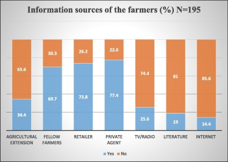

Fig. 1. Percentage of farmers using different information sources.

The data reveal that about one third of the respondents (34.4%) got their information on safe pesticide usage from the Department of Agriculture, while about 65.6% do not seek such information from this department, as indicated in Fig. 1. This might be because many of the representatives of the Department of Agriculture focus only on big land owners and ignore small and medium farmers. These results are in line with Lekei et al. (2014), who found that about 38.6% of farmers in Tanzania got their information from agricultural extension officers.

Fellow farmers also play an important role in disseminating information to farmers. The results show that about 69.7% of the respondents rely on information regarding safe pesticide usage provided by their fellow farmers, as compared to 30.3% who may not have had good relations with their neighboring farmers for social, economic, and political reasons. Rehman et al. (2013) reported that fellow farmers helped other farmers in selecting pesticides and provided information on their usage and proper handling. Similarly, Jors et al. (2014) conducted a study that evaluated the personal protection measures used to reduce pesticide poisoning among small holding farmers in Bolivia through the Farmer Field School (FFS) and the Neighbor Farmers. The findings of the study revealed that farmers were able to make improvements to personal protection measures with the help of neighboring farmers.

An overall 73.8% of respondents receive information from retailers, indicating their dependency on retailers when buying products on credit, while about 26.2% of the respondents might have been financially better off than others might and did not rely on retailers for information, as shown in Fig. 1. Research conducted in the past showed that retailers had not received any training and their information was poor concerning the harmful effects of pesticides and their toxicities or spraying safety techniques. These results are in agreement with Damalas and Khan, 2016, Lekei et al., 2014, who reported that most farmers get their information on safe pesticide usage from retailers. Zhang and Lu (2007) conducted a survey in northern China and found that 34.5% of respondents had received pesticide information from pesticide distributors; about 54.43% from co-workers; 41.09% from their own experience; and 25.79%, 16.67%, and 7.36% from TV, newspapers, and the Internet, respectively. These results contradict our findings. However, Weng and Black (2015) stated that retailers play an important role in influencing farmers, while reading labels on containers is not a way to change farmers’ attitudes. This might be because Chinese farmers are more educated and not fully dependent on a single source of information regarding the safe usage of pesticides.

Representatives of private pesticide companies play a crucial role in the dissemination of agricultural information. Although the main goal of pesticide companies is to sell their products, they still play a role in the capacity building of farmers by enhancing their knowledge, bringing about behavioral changes, introducing new technologies, and replacing old practices with new ones. The data presented in Fig. 1 reveal that more than two thirds of the respondents (77.4%) receive and follow instructions on the safe usage of pesticides made available by the agents/representatives of the pesticide companies, while only 22.6% do not receive information on safe pesticide usage from agents. These results are in line with Zhang and Lu’s (2007) findings.

The respondents who receive information regarding the safe application of pesticides from TV and radio, literature, and the Internet are shown in Fig. 1. About 25.6% of the respondents receive information on safe pesticide usage from TV, while nearly three quarters (74.4%) do not receive information from TV and radio. This might be due to their inability to purchase a TV and subsequent lack of a TV set at home. One study showed that technical handling of pesticides is be improved through FFS and short messages transmitted over the radio (Bentley et al., 2004).

Respondents who receive information on safe pesticide usage from literature accounted for 19%, and 81% of the respondents were not reading the literature. A total of 85.6% of respondents do not use the Internet as a source of information; only 14.4% use the Internet to obtain the latest information regarding new pesticides and safety measures to adopt.

#### 3.2.1. Level of the information received by the respondents from different sources

The level of information regarding safe pesticide usage that the farmers receive from different sources is measured using a nominal scale (Yes = 2 and No = 1). The data in Table 2 show that the majority of the respondents have a low level of information (65.6%) on safe pesticide usage. This might be due to their low level of education, as educational level is known to play an important role in increasing knowledge (Jensen et al., 2011). About one third of the respondents (34.4%) are provided with a medium level of information through the available sources, and no respondents receive a high level of information on safe pesticide usage.

Table 2. Level of information on safe pesticide usage received by respondents from different sources (N = 195).

| Level of information | Percentage (%) |
| --- | --- |
| Low (≤10) | 65.6 |
| Medium (11–14) | 34.4 |
| Total | 100.0 |

### 3.3. Reasons for pesticide usage

Fig. 2 lists the reasons for applying pesticides according to the respondents. The data reveal that the majority of the respondents apply pesticides to destroy/eradicate weeds (92.8%) or insects/pests (92.8%), and 87.7% apply pesticides to control diseases. Research has shown that about 55% yield losses occur due to weed infestations, insect/pest attacks, and disease outbreaks in field crops (Toxipedia.org, 2011). Our study indicates that farmers are well aware of the yield losses caused by weeds, insects/pests, and diseases. Rijal et al. (2018) reported that, in Nepal, about 80% of farmers were using chemicals/pesticides for pest management.

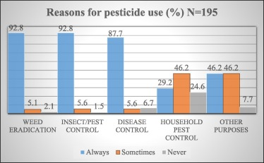

Fig. 2. Farmers’ reasons for applying pesticides.

### 3.4. Farmers’ problems during pesticide usage

Fig. 3 provides information on the problems faced by farmers’ regarding pesticide usage. A majority of the farmers (98.5%) report that they always face problems with the pesticide’s effectiveness or efficacy on insects, pests, and diseases. When asked about pesticide price fluctuations, a majority of the respondents (88.2%) say they always face this problem whenever they are in the market for pesticides. Only 7.2% of the respondents never face any problems regarding the price of pesticides.

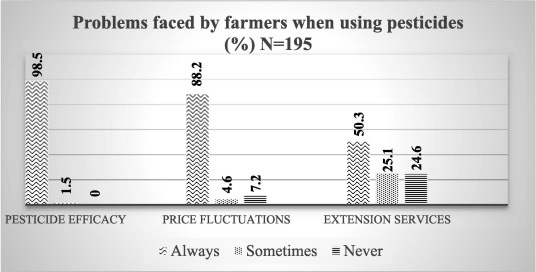

Fig. 3. Problems faced by farmers when using pesticides.

As regards the services offered by the extension department, about half of the respondents say they always face difficulties in receiving advice from the extension department, followed by 25.1% who sometimes face problems and about 24.6% who never face this kind of problem. Similar results were reported by Khan et al. (2015), indicating that inadequate services are provided to farmers by the extension department.

### 3.5. Respondents’ knowledge and practices regarding safe pesticide usage

The most common problems faced by the farmers regarding the use of pesticides are identified (based on the personal knowledge and experiences of farmers in the area, and informal conversations with them) and are presented in Table 3 in the form of 15 questions. When asked about their pesticide purchasing behavior, the majority of respondents (77.9%) say that they always purchase pesticides for only one crop, whereas 11.8% reply that they sometimes purchase pesticides to use on more than one crop, and 10.3% purchase pesticides immediately when they notice a pest attack on a particular crop and apply them to address the issue. Different studies conducted on the attitudes and knowledge of small landholders showed that the common pesticide use practices in developing countries are unsafe and cause health issues and environmental hazards (Macharia et al., 2013, Abang et al., 2014, Damte and Tabor, 2015).

Table 3. Respondents’ knowledge and practices regarding safe pesticide usage (dependent variables) N = 195.

[output not shown]

The present study reveals that a majority of respondents (48.2%) do not read the instructions written on pesticide bottles/containers. This is because most of the farmers are illiterate. The respondents that always read the instructions account for 17.4%, while 34.4% report that they sometimes read the instructions and sometimes do not. Damalas and Khan (2016) noted that the majority of farmers (73%) were not reading the instructions printed on bottles/containers of pesticides. Grey et al. (2006) found that pesticide bottle labels were helpful to them; however, due to low education levels of the farmers, they were unable to read the instructions written on the pesticide bottles/containers (Shetty et al., 2010).

Respondents who mix pesticides with their bare hands accounted for only 3.6%, while the majority of respondents (70.3%) avoid this. About 26.2% of respondents answer that they sometimes mix pesticides with their bare hands. Research conducted in Thailand by Jintana et al. (2009) showed that the majority of respondents (88.9%) mixed pesticides with their bare hands, 69.8% were using higher concentrations than recommended, and not a single respondent used PPE.

This study reveals that 21.5% of respondents blow into nozzles with their mouths to clear blockages, indicating poor practices. The study further reveals that nearly half of the respondents (49.7%) sometimes blow into nozzles with their mouths, whereas about 28.7% of respondents never use their mouths to clear a nozzle. The study further reveals that 29.2% of respondents clear nozzle blockages with wires instead of using their mouths. However, a majority of respondents (68.7%) sometimes uses wires but not always, and only 2.1% never use wires to clear nozzle blockages.

Respondents were asked about their use of gloves and masks for protection, and more than half (55.9%) answered “never,” followed by 41.5% who sometimes wear them, and the rest (2.6%), who always use gloves and masks to protect themselves from direct pesticide exposure. Devi (2009) observed that about 80% of Indian farmers covered their faces and heads with cloth but remained barefoot.

Regarding the wearing of long clothing, a majority of the respondents (92.8%) never wears it, but instead wear their regular clothes while spraying; only 2.1% of the respondents always wear long clothes when spraying. Smoking is a common behavior among the farmers. The data in Table 3 indicate that more than half of the respondents (54.4%) smoke during [pesticide application](https://www.sciencedirect.com/topics/earth-and-planetary-sciences/pesticide-application), while 30.3% answer that they sometimes smoke and only 15.4% never smoke during pesticide application. A study conducted by Sekiyama et al. (2007) in Indonesia revealed that most of the farmers did not wear safety gear, especially respirators/masks, and smoked during pesticide application, indicating a major threat to their health. Kachaiyaphum et al. (2010) indicated that three quarters of farmers (76%) in Thailand did not wear protective clothes and about 75% stored pesticides near food items. Studies conducted by Damalas et al., 2006, Isin and Yildirim, 2007, Yassin et al., 2002 produced similar results in Turkey, the Philippines, Gaza, and Greece respectively. Similarly, only about 40% of farmers in Iran use protective equipment when spraying (Hashemi et al., 2012).

While responding to the question “Do you use empty pesticide containers at your house?” almost all of the respondents show good knowledge about this statement. About 98.5% state that they never use empty containers at home. This finding contradicts Ibitayo (2006), who reported that about 80% of Egyptian farmers did not dispose of empty containers safely but instead used them to store drinking water. As little as 1.5% of respondents say they sometimes use them on an animal farm. Regarding the safe disposal of empty pesticide containers, the responses are not encouraging. About 73.8% of the respondents never dispose of pesticide containers according to the directions, but rather throw them away in a field and use them later. About 25.1% of respondents sometimes dispose of empty containers, and only 1% follow the directions written on the pesticide bottles/containers for safe disposal.

Regarding safety practices like taking a bath after pesticide application, about 45.6% do this after using pesticides on their crops. More than half of the respondents (54.4%) say that they sometimes take a shower and sometimes do not take a bath after the application of pesticides. Most of the respondents (41.5%) wash clothes that are contaminated with pesticides separately, while about 27.7% occasionally wash them separately; however, the rest of the respondents (30.8%) never wash their contaminated clothes separately. These results are in line with Weng and Black (2015), who stated that about 81.8% of Taiwanese farm workers take a shower immediately after pesticide application and change their contaminated clothes.

### 3.6. Regression model of farmers’ knowledge regarding safe pesticide usage (dependent variables)

Table 4. Result of logit regression model of farmers’ knowledge regarding safe pesticide usage (dependent variables).

| Dependent variable: Total safe use of pesticides; knowledge 1 = acceptable (above the mean), 0 = low (below the mean) Explanatory Variable | Dependent variable: Total safe use of pesticides; knowledge 1 = acceptable (above the mean), 0 = low (below the mean) β | Dependent variable: Total safe use of pesticides; knowledge 1 = acceptable (above the mean), 0 = low (below the mean) S.E. | Dependent variable: Total safe use of pesticides; knowledge 1 = acceptable (above the mean), 0 = low (below the mean) Wald | Dependent variable: Total safe use of pesticides; knowledge 1 = acceptable (above the mean), 0 = low (below the mean) D.F | Dependent variable: Total safe use of pesticides; knowledge 1 = acceptable (above the mean), 0 = low (below the mean) Significance (p value) |
| --- | --- | --- | --- | --- | --- |
| Age of the respondents | −1.78 | 1.48 | 1.35 | 1 | 0.42 ns |
| Education level | 2.56 | 0.71 | 6.2 | 1 | 0.01** |
| Occupation | 1.35 | 1.44 | 2.31 | 1 | 0.18 ns |
| Annual income | 1.59 | 1.06 | 2.52 | 1 | 0.17 ns |
| Land ownership | 2.11 | 0.95 | 5.26 | 1 | 0.03* |
| Total land size | 5.22 | 1.69 | 9.25 | 1 | 0.002** |
| Area under cultivation | −1.11 | 0.97 | 2.59 | 1 | 0.28 ns |
| Pesticide use period | −1.25 | 0.89 | 2.11 | 1 | 0.22 ns |
| Extension service as a source of information | −1.85 | 1.66 | 3.55 | 1 | 0.09 ns |
| Training | 4.85 | 1.48 | 10.55 | 1 | 0.001** |
| Constant | 2.18 | 2.46 | 0.000 | 1 | 1.000 |

−2log likelihood = 254.1, Nagelkerke's *R<sup>2</sup>* = 0.47. Level of significance: ** (P < 0.001); * (P < 0.05), ns = not significant.

The education level (0.01**) of the farmers has a significant effect on their knowledge of safety measures at the 0.01 level. Different studies conducted outside of Pakistan showed that farmers with better education histories and training in the use of PPE exhibited changed behaviors toward the adoptability of PPE (Blanco-Munoz and Lacasana, 2011, Al Zadjali et al., 2015).

The results show that the land ownership (0.03*) and total land size (0.002**) of the farmers significantly influences their likelihood of having better knowledge of safety measures while using pesticides at the 0.05 and 0.01 levels, respectively. This might be due to respondents who own land having better knowledge of the possible effects of pesticides on human health, soil, and the environment than those who rent land for crop cultivation, do not care about their own health, and are concerned only with how to maximize profits from the rented land. This study reveals that farmers who own land use pesticides judiciously, adopt safety measures, avoid deteriorating the soil, and work to preserve the environment for future generations. As many researchers (e.g., Pimentel, 2009, Hillocks, 2012) have stated, intensive use of pesticides in crop production results in reduced land yields, because it affects the soil, crops, and farmers. Landowners treat their lands as a valuable asset, and their value depends on their levels of productivity and soil quality. However, for rented lands, once the yields start decreasing, farmers generally return these lands to the owners and move on to rent other fertile (more productive) fields. Contradicting the above viewpoint, Rahman (2003) indicated that the use of pesticides increased alongside an increase for land owned by Bangladeshi farmers. Van der Hoek and Konradsen (2005) reported a similar trend for Singhalese farmers. Research in Pakistan showed that the socioeconomic characteristics of the respondents—such as high education level, high income, land size, and years of experience—greatly influenced the use of safety equipment and [willingness to pay](https://www.sciencedirect.com/topics/earth-and-planetary-sciences/willingness-to-pay) to avoid the risks associated with pesticides (Khan and Damalas, 2015).

The effect of training (0.001**) on the knowledge of safety measures to be observed when using pesticides is significant at the 0.01 level. Information received by the farmers from the agriculture extension department indicates non-significant trends in the regression model. This might be due to the farmers’ behavior, as they do not rely on extension services provided by the agriculture extension department; rather, they depend on their fellow farmers. Educational training programs based on safety precautions could be one way of avoiding the hazards of pesticide exposure (Ye et al., 2013). Blanco-Munoz and Lacasana (2011) mentioned that when it comes to the use of PPE, a significant change could come from farmer training.

### 3.7. Conclusion and recommendations

Pesticides can have negative effects on human health if they handled improperly. The adoption and application of safety measures are necessary to avoid the detrimental effects of pesticides. In this study, the results show that the middle-aged people of the villages are more engaged in agriculture and farming than the youth. Illiteracy is prevalent among farmers, and due to ignorance, they mainly rely on the advice of neighboring farmers and do not get information from the Department of Agriculture (Extension) on biosafety measures. This study also reveals that farmers do not follow the recommendations of the extension department or the instructions printed on pesticide bottles/containers. Based on the outcomes of this study, it is recommended that educational programs (formal and informal) and training in pesticide usage (Biosafety) be planned to assist farmers in enhancing their knowledge and skills, and to encourage them to adopt safety measures.

## Acknowledgements

The authors would like to thank the Deanship of Scientific Research and the RSSU for their technical support and the Deanship of Scientific Research (DSR) & Research Center, College of Food and Agriculture Sciences, King Saud University, for financial assistance. Special thanks to Muhammad Hussain and Mujahid Ali for their help in conducting the survey. Sincere thanks are due to Prof. Dr. Michael R. Reed, Director, International Programs for Agriculture at the University of Kentucky, USA and Dr. R. Kirby Barrick, Emeritus Professor, Agricultural Education and Communication University of Florida, USA for reviewing the initial drafts, making helful comments and valuable suggestions.

## References

**Abang et al., 2014**

A.F. Abang, C.M. Kouame, M. Abang, R. Hanna, A.K. Fotso

**Assessing vegetable farmer knowledge of diseases and insect pests of vegetable and management practices under tropical conditions**

Int. J. Vegetable Sci., 20 (2014), pp. 240-253

[CrossRef](https://doi.org/10.1080/19315260.2013.800625)[View Record in Scopus](https://www.scopus.com/inward/record.url?eid=2-s2.0-84902573607&partnerID=10&rel=R3.0.0)Google Scholar

**Abhilash and Singh, 2009**

P.C. Abhilash, N. Singh

**Pesticide use and application: an Indian scenario**

J. Hazard. Mater., 165 (2009), pp. 1-12

[Article](https://www.sciencedirect.com/science/article/pii/S0304389408015409)[Download PDF](https://www.sciencedirect.com/science/article/pii/S0304389408015409/pdfft?md5=8b905257fcb40cdedadaf884383e4af2&pid=1-s2.0-S0304389408015409-main.pdf)[View Record in Scopus](https://www.scopus.com/inward/record.url?eid=2-s2.0-64549105265&partnerID=10&rel=R3.0.0)[Google Scholar](https://scholar.google.com/scholar_lookup?title=Pesticide%20use%20and%20application%3A%20an%20Indian%20scenario&publication_year=2009&author=P.C.%20Abhilash&author=N.%20Singh)

**Ahmed et al., 2011**

A. Ahmed, M.A. Randhawa, M.J. Yusuf, N. Khalid

**Effect of processing on pesticide residues in food crops: a review**

J. Agric. Res., 49 (3) (2011), pp. 379-390

[View Record in Scopus](https://www.scopus.com/inward/record.url?eid=2-s2.0-84903245580&partnerID=10&rel=R3.0.0)Google Scholar

**Al Zadjali et al., 2015**

S. Al Zadjali, S. Morse, J. Chenoweth, M. Deadman

**Personal safety issues related to the use of pesticides in agricultural production in the Al-Batinah region of northern Oman**

Sci. Total Environ., 502 (2015), pp. 457-461

[Article](https://www.sciencedirect.com/science/article/pii/S0048969714013667)[Download PDF](https://www.sciencedirect.com/science/article/pii/S0048969714013667/pdfft?md5=3bfed8995fc50e5a01ed0d7e96796970&pid=1-s2.0-S0048969714013667-main.pdf)[View Record in Scopus](https://www.scopus.com/inward/record.url?eid=2-s2.0-84907687776&partnerID=10&rel=R3.0.0)Google Scholar

**Anwar et al., 2011**

T.A.H.I.R. Anwar, I. Ahmad, S.E.E.M.A. Tahir

**Determination of pesticide residues in fruits of Nawabshah district, Sindh, Pakistan**

Pakistan J. Bot., 43 (2011), pp. 1133-1139

[View Record in Scopus](https://www.scopus.com/inward/record.url?eid=2-s2.0-79955387200&partnerID=10&rel=R3.0.0)Google Scholar

**Bentley et al., 2004**

J.W. Bentley, O. Barea, S. Priou, H. Equise, G. Thicle

**Comparing farmers field schools, community workshops, and radio: teaching Bolivian farmers about Baterial wilt of potato**

J. Int. Agric. Ext. Educ., 14 (2004), pp. 45-61

www.plagbol.org.bo

[View Record in Scopus](https://www.scopus.com/inward/record.url?eid=2-s2.0-85023979145&partnerID=10&rel=R3.0.0)Google Scholar

**Bhutto and Bazmi, 2007**

Bhutto, A.W., Bazmi, A.A., 2007. Sustainable agriculture and eradication of rural poverty in Pakistan. In: Natural Resources Forum, vol. 31, No. 4. Blackwell Publishing Ltd, pp. 253–262.

Google Scholar

**Blanco-Munoz and Lacasana, 2011**

J. Blanco-Munoz, M. Lacasana

**Practices in pesticide handling and the use of personal protective equipment in Mexican agricultural workers**

J. Agromed., 16 (2) (2011), pp. 117-126

[View Record in Scopus](https://www.scopus.com/inward/record.url?eid=2-s2.0-79953681033&partnerID=10&rel=R3.0.0)Google Scholar

**Bolognesi and Merlo, 2011**

C. Bolognesi, F.D. Merlo

**Pesticides: Human Health Effects**

National Cancer Research Institute, Genoa, Italy (2011)

[Google Scholar](https://scholar.google.com/scholar_lookup?title=Pesticides%3A%20Human%20Health%20Effects&publication_year=2011&author=C.%20Bolognesi&author=F.D.%20Merlo)

**Coronado, 2012**

G.D. Coronado

**Do work place and home protective practices protect farm workers? Findings from the “For healthy Kids” study**

J. Occup. Environ. Med., 54 (9) (2012), pp. 1163-1169

[View Record in Scopus](https://www.scopus.com/inward/record.url?eid=2-s2.0-84866363488&partnerID=10&rel=R3.0.0)[Google Scholar](https://scholar.google.com/scholar?q=Do%20work%20place%20and%20home%20protective%20practices%20protect%20farm%20workers%20Findings%20from%20the%20For%20healthy%20Kids%20study)

**Damalas and Khan, 2016**

C.A. Damalas, M. Khan

**Farmers’ attitudes towards pesticide labels: Implications for personal and environmental safety**

Int. J. Pest Manage., 62 (2016), pp. 319-325

[CrossRef](https://doi.org/10.1080/09670874.2016.1195027)[View Record in Scopus](https://www.scopus.com/inward/record.url?eid=2-s2.0-84974822287&partnerID=10&rel=R3.0.0)[Google Scholar](https://scholar.google.com/scholar?q=Farmers%20attitudes%20towards%20pesticide%20labels:%20Implications%20for%20personal%20and%20environmental%20safety)

17

0

**Damalas et al., 2006**

C.A. Damalas, E.B. Georgiou, M.G. Theodorou

**Pesticide use and safety practices among Greek tobacco farmers: a survey**

Int. J. Environ. Health Res., 16 (5) (2006), pp. 339-348

[CrossRef](https://doi.org/10.1080/09603120600869190)[View Record in Scopus](https://www.scopus.com/inward/record.url?eid=2-s2.0-33749014409&partnerID=10&rel=R3.0.0)Google Scholar

61

0

**Damte and Tabor, 2015**

T. Damte, G. Tabor

**Small-scale vegetable producers’ perception of pests and pesticide uses in East Shewa zone Ethiopia**

Int. J. Pest Manage., 61 (3) (2015), pp. 212-219

[CrossRef](https://doi.org/10.1080/09670874.2015.1036822)[View Record in Scopus](https://www.scopus.com/inward/record.url?eid=2-s2.0-84930926362&partnerID=10&rel=R3.0.0)[Google Scholar](https://scholar.google.com/scholar?q=Small-scale%20vegetable%20producers%20perception%20of%20pests%20and%20pesticide%20uses%20in%20East%20Shewa%20zone%20Ethiopia)

19

0

**Devi, 2009**

P.I. Devi

**Health risk perceptions, awareness and handling behaviour of pesticides by farm workers**

Agric. Econ. Res. Rev., 22 (2) (2009)

[Google Scholar](https://scholar.google.com/scholar_lookup?title=Health%20risk%20perceptions%2C%20awareness%20and%20handling%20behaviour%20of%20pesticides%20by%20farm%20workers&publication_year=2009&author=P.I.%20Devi)

**Ejaz et al., 2004**

S. Ejaz, W. Akram, C.W. Lim, J.J. Lee, I. Hussain

**Endocrine disrupting pesticides: a leading cause of cancer among rural people in Pakistan**

Exp. Oncol., 26 (2) (2004), pp. 98-105

[View Record in Scopus](https://www.scopus.com/inward/record.url?eid=2-s2.0-3242777060&partnerID=10&rel=R3.0.0)Google Scholar

**Government of Pakistan (GOP). Economic survey, 2016**

Government of Pakistan (GOP). Economic survey (2016). Islamabad; Ministry of Finance, Pakistan, pp. 23–24.

[Google Scholar](https://scholar.google.com/scholar?q=Government%20of%20Pakistan%20.%20Economic%20survey%20.%20Islamabad;%20Ministry%20of%20Finance,%20Pakistan,%20pp.%202324.)

**Grey et al., 2006**

C.N. Grey, M.J. Nieuwenhuijsen, J. Golding, Team, A.L.S.P.A.C

**Use and storage of domestic pesticides in the UK**

Sci. Total Environ., 368 (2–3) (2006), pp. 465-470

[Article](https://www.sciencedirect.com/science/article/pii/S0048969706002142)[Download PDF](https://www.sciencedirect.com/science/article/pii/S0048969706002142/pdfft?md5=dc9a253ea97192f930b219b4f4815f61&pid=1-s2.0-S0048969706002142-main.pdf)[View Record in Scopus](https://www.scopus.com/inward/record.url?eid=2-s2.0-33746651797&partnerID=10&rel=R3.0.0)Google Scholar

**Grube et al., 2011**

A. Grube, D. Donaldson, T. Kiely, L. Wu

**Pesticides Industry Sales and Usage**

US EPA, Washington, DC (2011)

[Google Scholar](https://scholar.google.com/scholar_lookup?title=Pesticides%20Industry%20Sales%20and%20Usage&publication_year=2011&author=A.%20Grube&author=D.%20Donaldson&author=T.%20Kiely&author=L.%20Wu)

**Hashemi et al., 2012**

S.M. Hashemi, R. Rostami, M.K. Hashemi, C.A. Damalas

**Pesticide use and risk perceptions among farmers in southwest Iran**

Human Ecol. Risk Assess.: Int. J., 18 (2) (2012), pp. 456-470

[CrossRef](https://doi.org/10.1080/10807039.2012.652472)[View Record in Scopus](https://www.scopus.com/inward/record.url?eid=2-s2.0-84859391708&partnerID=10&rel=R3.0.0)Google Scholar

57

0

**Hillocks, 2012**

R.J. Hillocks

**Farming with fewer pesticides: EU pesticide review and resulting challenges for UK agriculture**

Crop Prot., 31 (1) (2012), pp. 85-93

[Article](https://www.sciencedirect.com/science/article/pii/S026121941100264X)[Download PDF](https://www.sciencedirect.com/science/article/pii/S026121941100264X/pdfft?md5=baf1d486db84f637be1321b5f4fb2f38&pid=1-s2.0-S026121941100264X-main.pdf)[View Record in Scopus](https://www.scopus.com/inward/record.url?eid=2-s2.0-80155128972&partnerID=10&rel=R3.0.0)Google Scholar

**Ibitayo, 2006**

O.O. Ibitayo

**Egyptian farmers’attitudes and behaviors regarding agricultural pesticides: implications for pesticide risk communication**

Risk Anal., 26 (2006), pp. 989-995

[CrossRef](https://doi.org/10.1111/j.1539-6924.2006.00794.x)[View Record in Scopus](https://www.scopus.com/inward/record.url?eid=2-s2.0-33748428768&partnerID=10&rel=R3.0.0)[Google Scholar](https://scholar.google.com/scholar?q=Egyptian%20farmersattitudes%20and%20behaviors%20regarding%20agricultural%20pesticides:%20implications%20for%20pesticide%20risk%20communication)

59

1

**Isin and Yildirim, 2007**

S. Isin, I. Yildirim

**Fruit-growers’ perceptions on the harmful effects of pesticides and their reflection on practices: The case of Kemalpasa Turkey**

Crop Prot., 26 (7) (2007), pp. 917-922

[Article](https://www.sciencedirect.com/science/article/pii/S0261219406002250)[Download PDF](https://www.sciencedirect.com/science/article/pii/S0261219406002250/pdfft?md5=ddc3d6abd7f1880490aa7f505fc3471c&pid=1-s2.0-S0261219406002250-main.pdf)[View Record in Scopus](https://www.scopus.com/inward/record.url?eid=2-s2.0-34248201644&partnerID=10&rel=R3.0.0)[Google Scholar](https://scholar.google.com/scholar?q=Fruit-growers%20perceptions%20on%20the%20harmful%20effects%20of%20pesticides%20and%20their%20reflection%20on%20practices:%20The%20case%20of%20Kemalpasa%20Turkey)

**Jensen et al., 2011**

H.K. Jensen, F. Konradsen, E. Jørs, J.H. Petersen, A. Anders

**Pesticide use and self-reported symptoms of acute pesticide poisoning among aquatic farmers in phnom penh**

J. Toxicol. (2011), p. 639814]

[http://www.hindawi.com/journals/jt/2011/639814/cta/

Google Scholar

**Jintana et al., 2009**

S. Jintana, K. Sming, Y. Krongtong, S. Thanyachai

**Cholinesterase activity, pesticide exposure and health impact in a population exposed to organophosphates**

Int. Arch. Occup. Environ. Health, 82 (7) (2009), pp. 833-842

[CrossRef](https://doi.org/10.1007/s00420-009-0422-9)[View Record in Scopus](https://www.scopus.com/inward/record.url?eid=2-s2.0-67649321640&partnerID=10&rel=R3.0.0)Google Scholar

41

1

**Jors et al., 2014**

E. Jors, F. Lander, O. Huici, R.C. Morant, G. Gulis, F. Konradsen

**Do Bolivian small holder farmers improve and retain knowledge to reduce occupational pesticide poisonings after training on Integrated Pest Management?**

Environ. Health, 13 (1) (2014), p. 75

[View Record in Scopus](https://www.scopus.com/inward/record.url?eid=2-s2.0-84907964885&partnerID=10&rel=R3.0.0)Google Scholar

**Kachaiyaphum et al., 2010**

P. Kachaiyaphum, N. Howteerakul, D. Sujirarat, S. Siri, N. Suwannapong

**Serum cholinesterase levels of Thai chilli-farm workers exposed to chemical pesticides: prevalence estimates and associated factors**

J. Occup. Health, 52 (1) (2010), pp. 89-98

[View Record in Scopus](https://www.scopus.com/inward/record.url?eid=2-s2.0-77952294141&partnerID=10&rel=R3.0.0)Google Scholar

**Kesavachandran et al., 2009**

Kesavachandran, C.N., Fareed, M., Pathak, M.K., Bihari, V., Mathur, N., Srivastava, A.K., 2009. Adverse health effects of pesticides in agrarian populations of developing countries. In: Reviews of Environmental Contamination and Toxicology, vol 200. Springer US, pp. 33–52.

Google Scholar

**Khan et al., 2015**

A.A. Khan, Z. Muhammad, M. Muhammad, L.K. Inamullah, B. Muhammad, R. Fazal, B. Nadia

**The role of agricultural extension services in tomato Production in district Mansehra Khyber Pakhtunkhwa**

ARPN J. Agric. Biol. Sci., 10 (5) (2015), pp. 200-205

[View Record in Scopus](https://www.scopus.com/inward/record.url?eid=2-s2.0-85062651620&partnerID=10&rel=R3.0.0)Google Scholar

**Khan, 2012**

Khan, M., 2012. Adverse health experiences, risk perception and pesticide use behavior, Unpublished PhD Thesis. Islamabad: School of Economics Sciences, Federal Urdu University of Arts, Science and Technology; Retrieved from http://eprints.hec.gov.pk/8103/1/1608S.htm.

Google Scholar

**Khan and Iqbal, 2009**

M.A. Khan, M. Iqbal

**Sustainable cotton production through skill development among farmers: evidence from Khairpur district of Sindh, Pakistan**

Pakistan Dev. Rev., 44 (2009), pp. 695-716

Google Scholar

**Khan et al., 2010**

M.J. Khan, M.S. Zia, M. Qasim

**Use of pesticides and their role in environmental pollution**

World Acad. Sci. Eng. Technol., 72 (2010), pp. 122-128

[Google Scholar](https://scholar.google.com/scholar_lookup?title=Use%20of%20pesticides%20and%20their%20role%20in%20environmental%20pollution&publication_year=2010&author=M.J.%20Khan&author=M.S.%20Zia&author=M.%20Qasim)

**Khan and Damalas, 2015**

M. Khan, C.A. Damalas

**Farmers' willingness to pay for less health risks by pesticide use: A case study from the cotton belt of Punjab, Pakistan**

Sci. Total Environ., 530 (2015), pp. 297-303

[Article](https://www.sciencedirect.com/science/article/pii/S0048969715301686)[Download PDF](https://www.sciencedirect.com/science/article/pii/S0048969715301686/pdfft?md5=bc083a62447c72702c4ee079277ea422&pid=1-s2.0-S0048969715301686-main.pdf)[Google Scholar](https://scholar.google.com/scholar?q=Farmers%20willingness%20to%20pay%20for%20less%20health%20risks%20by%20pesticide%20use:%20A%20case%20study%20from%20the%20cotton%20belt%20of%20Punjab,%20Pakistan)

**Konradsen et al., 2007**

F. Konradsen, R. Pieris, M. Weerasinghe, W. Van der Hoek, M. Eddleston, A.H. Dawson

**Community uptake of safe storage boxes to reduce self-poisoning from pesticides in rural Sri Lanka**

BMC Public Health, 7 (1) (2007), p. 13

[View Record in Scopus](https://www.scopus.com/inward/record.url?eid=2-s2.0-33846900401&partnerID=10&rel=R3.0.0)Google Scholar

**Lekei et al., 2014**

E.E. Lekei, A.V. Ngowi, L. London

**Farmers' knowledge, practices and injuries associated with pesticide exposure in rural farming villages in Tanzania**

BMC Public Health, 14 (2014), p. 389

[Google Scholar](https://scholar.google.com/scholar?q=Farmers%20knowledge,%20practices%20and%20injuries%20associated%20with%20pesticide%20exposure%20in%20rural%20farming%20villages%20in%20Tanzania)

**MacFarlane et al., 2013**

F. MacFarlane, R. Carey, T. Keegel, S. El-Zaemay, L. Fritschi

**Dermal exposure associated with occupational end use of pesticides and the role of protective measures**

Safety Health Work, 4 (2013), pp. 136-141

[View Record in Scopus](https://www.scopus.com/inward/record.url?eid=2-s2.0-84884701129&partnerID=10&rel=R3.0.0)Google Scholar

**Macharia et al., 2013**

I. Macharia, D. Mithofer, H. Waibel

**Pesticide handling practices by vegetable farmer in Kenya**

Environ. Dev. Sustain., 15 (2013), pp. 887-902

[CrossRef](https://doi.org/10.1007/s10668-012-9417-x)[View Record in Scopus](https://www.scopus.com/inward/record.url?eid=2-s2.0-84879781497&partnerID=10&rel=R3.0.0)[Google Scholar](https://scholar.google.com/scholar_lookup?title=Pesticide%20handling%20practices%20by%20vegetable%20farmer%20in%20Kenya&publication_year=2013&author=I.%20Macharia&author=D.%20Mithofer&author=H.%20Waibel)

30

1

**McDougall, 2018-2012**

McDougall, P., AgriService. 2008-2012. Proprietary Agriservice databases and analyses for international and U.S. pesticide use. http://phillipsmcdougall.co.uk/agriservice/.

Google Scholar

**Medline Plus, 2015**

Medline Plus, 2015. Insecticide poisoning. US National Library. www.nlm.nih.gov › Home › Medical Encyclopedi (accessed 03.11.15).

[Google Scholar](https://scholar.google.com/scholar?q=Medline%20Plus,%202015.%20Insecticide%20poisoning.%20US%20National%20Library.%20www.nlm.nih.gov%20%20Home%20%20Medical%20Encyclopedi%20.)

**Okoffo et al., 2016**

E.D. Okoffo, M. Mensah, B.Y. Fosu-Mensah

**Pesticides exposure and the use of personal protective equipment by cocoa farmers in Ghana**

Environ. Syst. Res., 5 (1) (2016), p. 17

[View Record in Scopus](https://www.scopus.com/inward/record.url?eid=2-s2.0-84989278382&partnerID=10&rel=R3.0.0)Google Scholar

**PSEP, 2015**

Pesticide Safety Education Program (PSEP), 2015. Symptoms of pesticide poisoning. Cornell University, cooperative extension, module 9. http://psep.cce.cornell.edu/Tutorials/core-tutorial/module09/index.aspx.

Google Scholar

**Pimentel, 2009**

D. Pimentel

**Integrated Pest Management: Innovation-development Process**

Springer, Amsterdam (2009)

[Google Scholar](https://scholar.google.com/scholar_lookup?title=Integrated%20Pest%20Management%3A%20Innovation-development%20Process&publication_year=2009&author=D.%20Pimentel)

**Rahman, 2003**

S. Rahman

**Profit efficiency among Bangladeshi rice farmers**

Food Policy, 28 (5–6) (2003), pp. 487-503

[Article](https://www.sciencedirect.com/science/article/pii/S0306919203000745)[Download PDF](https://www.sciencedirect.com/science/article/pii/S0306919203000745/pdfft?md5=1f0ea30d496cc1a81d39af40cbdba665&pid=1-s2.0-S0306919203000745-main.pdf)[View Record in Scopus](https://www.scopus.com/inward/record.url?eid=2-s2.0-1642562548&partnerID=10&rel=R3.0.0)[Google Scholar](https://scholar.google.com/scholar_lookup?title=Profit%20efficiency%20among%20Bangladeshi%20rice%20farmers&publication_year=2003&author=S.%20Rahman)

**Rehman et al., 2013**

F. Rehman, S. Muhammad, I. Ashraf, K.M. Ch, T. Ruby

**Effect of farmers’ socioeconomic characteristics on access to agricultural information: empirical evidence from Pakistan**

Young (Up to 35), 52 (2013), pp. 21-67

[View Record in Scopus](https://www.scopus.com/inward/record.url?eid=2-s2.0-85056170696&partnerID=10&rel=R3.0.0)[Google Scholar](https://scholar.google.com/scholar?q=Effect%20of%20farmers%20socioeconomic%20characteristics%20on%20access%20to%20agricultural%20information:%20empirical%20evidence%20from%20Pakistan)

**Rijal et al., 2018**

J.P. Rijal, R. Regmi, R. Ghimire, K.D. Puri, S. Gyawaly, S. Poudel

**Farmers’ knowledge on pesticide safety and pest management practices: a case study of vegetable growers in Chitwan, Nepal**

Agriculture, 8 (1) (2018), p. 16

[CrossRef](https://doi.org/10.3390/agriculture8010016)[View Record in Scopus](https://www.scopus.com/inward/record.url?eid=2-s2.0-85041425339&partnerID=10&rel=R3.0.0)[Google Scholar](https://scholar.google.com/scholar?q=Farmers%20knowledge%20on%20pesticide%20safety%20and%20pest%20management%20practices:%20a%20case%20study%20of%20vegetable%20growers%20in%20Chitwan,%20Nepal)

43

1

**Rios-Gonzalez et al., 2013**

A. Rios-Gonzalez, K. Jansen, H.J. Sanchez-Perez

**Pesticide risk perceptions and the differences between farmers and extensionists: Towards a knowledge-in-context model**

Environ. Res., 124 (2013), pp. 43-53

[Article](https://www.sciencedirect.com/science/article/pii/S0013935113000650)[Download PDF](https://www.sciencedirect.com/science/article/pii/S0013935113000650/pdfft?md5=1df1b08f31cfa109727288c5c2149cb4&pid=1-s2.0-S0013935113000650-main.pdf)[View Record in Scopus](https://www.scopus.com/inward/record.url?eid=2-s2.0-84878382437&partnerID=10&rel=R3.0.0)Google Scholar

**Sekiyama et al., 2007**

M. Sekiyama, M. Tanaka, B. Gunawan, O. Abdoellah, C. Watanabe

**Pesticide usage and its association with health symptoms among farmers in rural villages in West Java Indonesia**

Environ. Sci., 14 (Suppl) (2007), pp. 23-33

[View Record in Scopus](https://www.scopus.com/inward/record.url?eid=2-s2.0-50649110353&partnerID=10&rel=R3.0.0)Google Scholar

**Shetty et al., 2010**

P.K. Shetty, M. Murugan, M.B. Hiremath, K.G. Sreeja

**Farmers’ education and perception on pesticide use and crop economies in Indian agriculture**

J. Exp. Sci., 1 (1) (2010)

[Google Scholar](https://scholar.google.com/scholar?q=Farmers%20education%20and%20perception%20on%20pesticide%20use%20and%20crop%20economies%20in%20Indian%20agriculture)

**Toxipedia.org., 2011**

Toxipedia.org, 2011. Pesticide use statistics. Available from: http://toxipedia.org/display/toxipedia/Pesticide1Use1Statistics (accessed November 2013).

[Google Scholar](https://scholar.google.com/scholar?q=Toxipedia.org,%202011.%20Pesticide%20use%20statistics.%20Available%20from:%20http:toxipedia.orgdisplaytoxipediaPesticide1Use1Statistics%20.)

**Van Der Hoek and Konradsen, 2005**

W. Van Der Hoek, F. Konradsen

**Risk factors for acute pesticide poisoning in Sri Lanka**

Trop. Med. Int. Health, 10 (6) (2005), pp. 589-596

[CrossRef](https://doi.org/10.1111/j.1365-3156.2005.01416.x)[View Record in Scopus](https://www.scopus.com/inward/record.url?eid=2-s2.0-20444374737&partnerID=10&rel=R3.0.0)[Google Scholar](https://scholar.google.com/scholar_lookup?title=Risk%20factors%20for%20acute%20pesticide%20poisoning%20in%20Sri%20Lanka&publication_year=2005&author=W.%20Van%20Der%20Hoek&author=F.%20Konradsen)

89

7

**Weng and Black, 2015**

C. Weng, C. Black

**Taiwanese farm workers’ pesticide knowledge, attitudes, behaviors and clothing practices**

Int. J. Environ. Health Res., 25 (2015), pp. 685-696, 10.1080/09603123.2015.1020415

[View Record in Scopus](https://www.scopus.com/inward/record.url?eid=2-s2.0-84944179915&partnerID=10&rel=R3.0.0)[Google Scholar](https://scholar.google.com/scholar?q=Taiwanese%20farm%20workers%20pesticide%20knowledge,%20attitudes,%20behaviors%20and%20clothing%20practices)

8

2

**Yassin et al., 2002**

M.M. Yassin, T.A. Mourad, J.M. Safi

**Knowledge, attitude, practice, and toxicity symptoms associated with pesticide use among farm workers in the Gaza Strip**

Occup. Environ. Med., 59 (6) (2002), pp. 387-393

[View Record in Scopus](https://www.scopus.com/inward/record.url?eid=2-s2.0-0036282235&partnerID=10&rel=R3.0.0)Google Scholar

**Ye et al., 2013**

M. Ye, J. Beach, J.W. Martin, A. Senthilselvan

**Occupational pesticide exposures and respiratory health**

Int. J. Environ. Res. Public Health, 10 (2013), pp. 6442-6471, 10.3390/ijerph10126442

[View Record in Scopus](https://www.scopus.com/inward/record.url?eid=2-s2.0-84888413252&partnerID=10&rel=R3.0.0)Google Scholar

106

0

**Zhang and Lu, 2007**

H. Zhang, Y. Lu

**End-users’ knowledge, attitude, and behavior towards safe use of pesticides: a case study in the Guanting Reservoir area China**

Environ. Geochem Health, 29 (2007), pp. 513-520

[CrossRef](https://doi.org/10.1007/s10653-007-9120-2)[View Record in Scopus](https://www.scopus.com/inward/record.url?eid=2-s2.0-35449000068&partnerID=10&rel=R3.0.0)[Google Scholar](https://scholar.google.com/scholar?q=End-users%20knowledge,%20attitude,%20and%20behavior%20towards%20safe%20use%20of%20pesticides:%20a%20case%20study%20in%20the%20Guanting%20Reservoir%20area%20China)

7

0

**Zia et al., 2009**

M.S. Zia, M.J. Khan, M. Qasim, A. Rehman

**Pesticide residue in the food chain and human body inside Pakistan**

J. Chem. Soc. Pak., 31 (2009), pp. 284-291

[View Record in Scopus](https://www.scopus.com/inward/record.url?eid=2-s2.0-70349222720&partnerID=10&rel=R3.0.0)Google Scholar

- 2022, Heliyon

### The impact of different education strategies on rice farmers’ knowledge, attitude and practice (KAP) about pesticide use

- 2021, Journal of the Saudi Society of Agricultural Sciences

### Farmers' behavior towards safe pesticide handling: An analysis with the theory of planned behavior

- 2021, Science of the Total Environment

### Understanding farmers’ safety behavior regarding pesticide use in Morocco

- 2021, Sustainable Production and Consumption

### Characteristics and adverse consequences on human health of agrochemicals used in Cuban agriculture

- 2022, Revista Cubana de Salud Publica

### Effects of Market Incentives and Livelihood Dependence on Farmers’ Multi-Stage Pesticide Application Behavior—A Case Study of Four Provinces in China

- 2022, International Journal of Environmental Research and Public Health

[View all citing articles on Scopus](http://www.scopus.com/scopus/inward/citedby.url?partnerID=10&rel=3.0.0&eid=2-s2.0-85062672969&md5=717b47fffd99a5ae14f9df18e398c69)

Peer review under responsibility of King Saud University.

© 2019 Production and hosting by Elsevier B.V. on behalf of King Saud University.

- Saudi Journal of Biological Sciences, Volume 26, Issue 7, 2019, pp. 1911-1914

### Perceptions of pesticides exposure risks by operators, workers, residents and bystanders in Greece, Italy and the UK

- Science of The Total Environment, Volume 505, 2015, pp. 1082-1092

### Farmers' willingness to pay for less health risks by pesticide use: A case study from the cotton belt of Punjab, Pakistan

- Science of The Total Environment, Volumes 530–531, 2015, pp. 297-303

Citations

Captures

Mentions

- References: 1

Social Media

- Shares, Likes & Comments: 12

[View details](https://plu.mx/plum/a/?doi=10.1016/j.sjbs.2019.03.001&theme=plum-sciencedirect-theme&hideUsage=true)

[figure not shown]

25

0